# Data visualiseren met R

Op deze pagina vind je enkele demonstraties van hoe je R kan gebruiken om data te visualiseren.

Meer informatie over hoe je deze pagina kan gebruiken vind je in deze handleiding.

De analyse gebeurt met behulp van R en RStudio. Een inleiding tot deze software vind je [hier](https://ufora.ugent.be/d2l/le/discovery/view/course/386505).

# 1 Doel

Visualiseren helpt om inzicht te krijgen in data. Onderzoekers gebruiken visualisaties vaak in de verkennende fase van een studie, als manier om zich een eerste indruk te vormen van een dataset. Het kan eveneens nuttig - soms zelfs noodzakelijk - zijn wanneer je de resultaten van je studie wil communiceren naar je doelpubliek.

Op deze pagina focussen we op de praktische kant: hoe kan je data visualiseren met R? Er bestaan al heel wat mogelijkheden met de basisversie van R (“base R”). Hieronder vind je voorbeelden van wat je daarmee kan bereiken. Daarnaast bestaat er ook een package `ggplot2` dat speciaal ontworpen is met het oog op datavisualisatie. Dat biedt nog meer mogelijkheden, maar is ook wat moeilijker om aan te leren. `ggplot2` wordt elders gedemonstreerd.

Hieronder vind je voorbeelden van verschillende types visualisaties (histogram, boxplot, enz.). Er is geen ellenlange uitleg voorzien bij elk type. Soms vind je in het lichtblauwe blok wat commentaar bij de code zelf (rechts van de `#`).

# 2 De dataset

De dataset enquete bevat gegevens van 14 variabelen geobserveerd bij 42 Amerikaanse studenten die een vak statistiek volgen. Deze dataset is gebaseerd op een dataset die [hier](https://vincentarelbundock.github.io/Rdatasets/doc/Stat2Data/Day1Survey.html) wordt beschreven.

Deze dataset kan je inladen met de functie `read.csv()`. De data kan je best meteen in een object `enquete` onderbrengen zodat je die later makkelijk opnieuw kan oproepen.

```r
enquete <- read.csv("https://statlas.ugent.be/datasets/enquete_vis.csv")
```

Je kan het dataframe `enquete` beginnen verkennen met bijvoorbeeld de functie `str()`.

```r
str(enquete)
```

```
'data.frame':   42 obs. of  14 variables:
 $ Index         : int  1 2 3 4 5 6 7 8 9 10 ...
 $ Sectie        : int  1 1 1 1 1 1 1 1 1 1 ...
 $ Jaar          : chr  "Vierde jaar" "Eerste jaar" "Eerste jaar" "Eerste jaar" ...
 $ Geslacht      : chr  "Vrouw" "Vrouw" "Vrouw" "Man" ...
 $ Afstand       : num  644 724 4828 161 3219 ...
 $ Lengte        : num  157 155 155 183 175 ...
 $ Dominante.hand: chr  "Rechts" "Links" "Rechts" "Rechts" ...
 $ Munten        : num  1.12 29 1.5 0.07 0.12 8 0.77 0 0 0 ...
 $ Wit.koord     : num  106.7 114.3 55.9 101.6 121.9 ...
 $ Zwart.koord   : num  15.2 12.7 10.2 10.2 17.8 ...
 $ Lezen         : num  80 100 100 50 200 100 200 100 100 100 ...
 $ Tv            : num  3 10 4 25 5 0 2 2 20 20 ...
 $ Hartslag      : int  71 78 80 63 63 56 72 66 54 48 ...
 $ Berichten     : int  3 100 2 200 100 1 50 30 40 25 ...
```

In de output zie je dat er verschillende types variabelen te vinden zijn in `enquete`. De types `int` en `num` staan beide voor metrische variabelen. `chr` slaat op tekstuele informatie. Dat zie je ook aan de aanhalingstekens rondom de waarden voor deze variabelen.

Eigenlijk is het gebruik van `chr` niet ideaal. Dit datatype is meer geschikt voor eigennamen, zoals voor- en familienamen van individuen. Wanneer een vector waarden van een categorische variabele bevat kan je beter opteren voor het datatype `factor`.

Een vector omzetten van type `chr` naar type `factor` is eenvoudig. Hieronder doen we dat voor alle `chr` variabelen in de dataset.

```r
enquete$Jaar <- factor(enquete$Jaar)
enquete$Geslacht <- factor(enquete$Geslacht)
enquete$Dominante.hand <- factor(enquete$Dominante.hand)
```

# 3 Histogram

Een histogram laat je toe om de verdeling van een continue variabele weer te geven. Hieronder gaat het om de afstand die studenten moeten afleggen om op hun campus te raken.

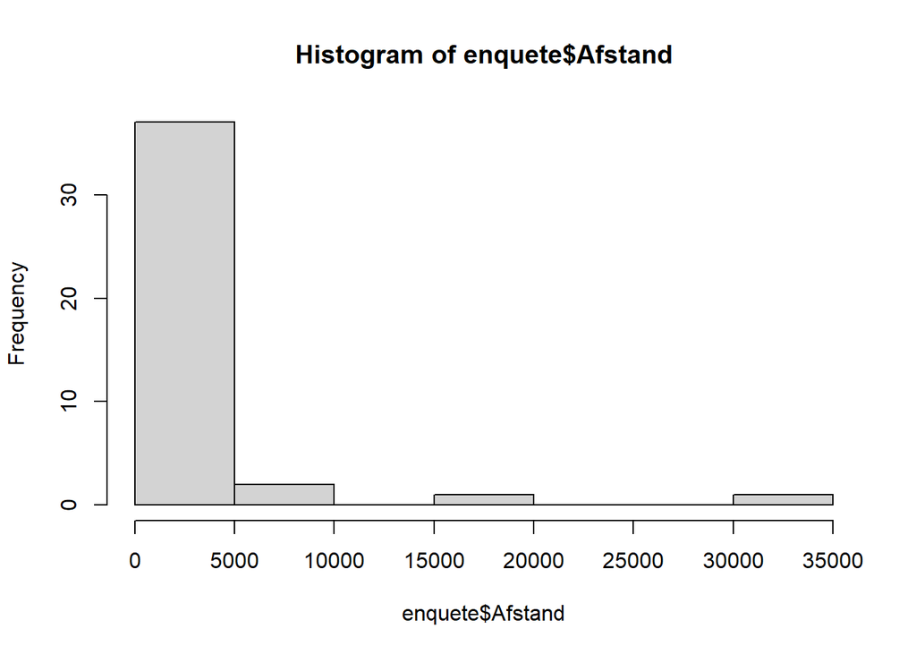

```r
hist(enquete$Afstand)
```

De waarden van de continue variabele worden in klassen ingedeeld. Het aantal klassen en/of de grenswaarden tussen de klassen kan je zelf controleren.

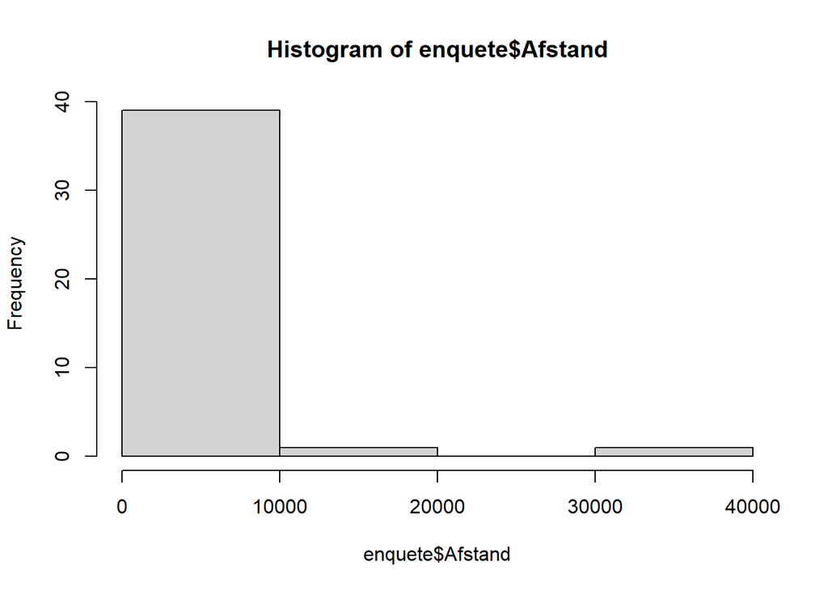

```r
hist(enquete$Afstand, breaks = 4) # kies het aantal klassen
```

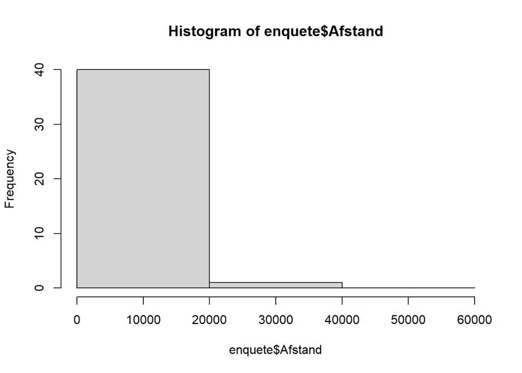

```r
hist(enquete$Afstand, breaks = c(0, 20000, 40000, 60000)) # bepaal de klassengrenzen
```

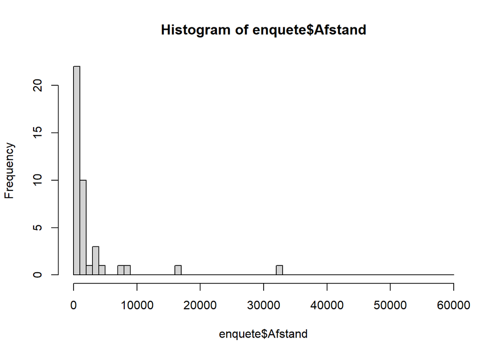

```r
hist(enquete$Afstand, breaks = seq(from=0, to=60000, by=1000)) # bepaal de klassengrenzen
```

# 4 Staafdiagram

Staafdiagrammen tonen de frequentie van de waarden van een categorische variabele, in dit geval de dominante hand. De functie daarvoor heet `barplot()`. Aan deze functie kan je niet gewoon de categorische variabele zelf geven. Dat leidt tot een foutmelding.

```r
barplot(enquete$Dominante.hand)
```

```
Error in barplot.default(enquete$Dominante.hand): 'height' must be a vector or a matrix
```

In plaats daarvan gebruik je eerst de functie `table()` om de frequenties te bekomen.

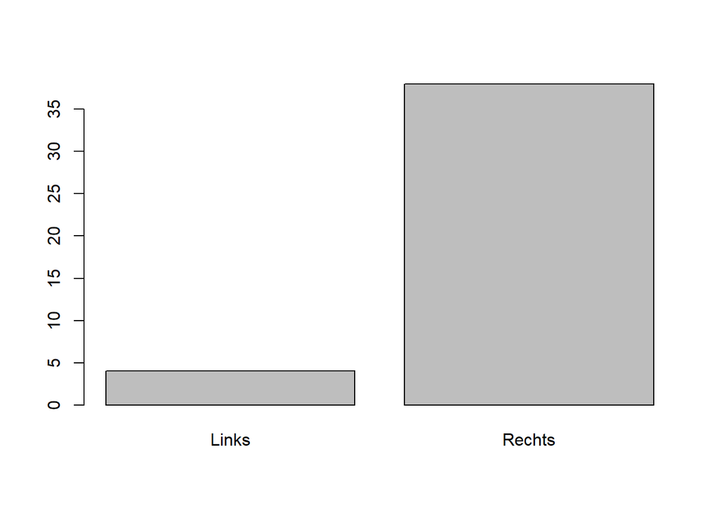

```r
barplot(table(enquete$Dominante.hand))
```

# 5 Boxplot

De functie `boxplot()` levert niet zo verrassend een boxplot op. Hieronder gaat het om het aantal berichten dat een student de voorbije 24 uur heeft gestuurd.

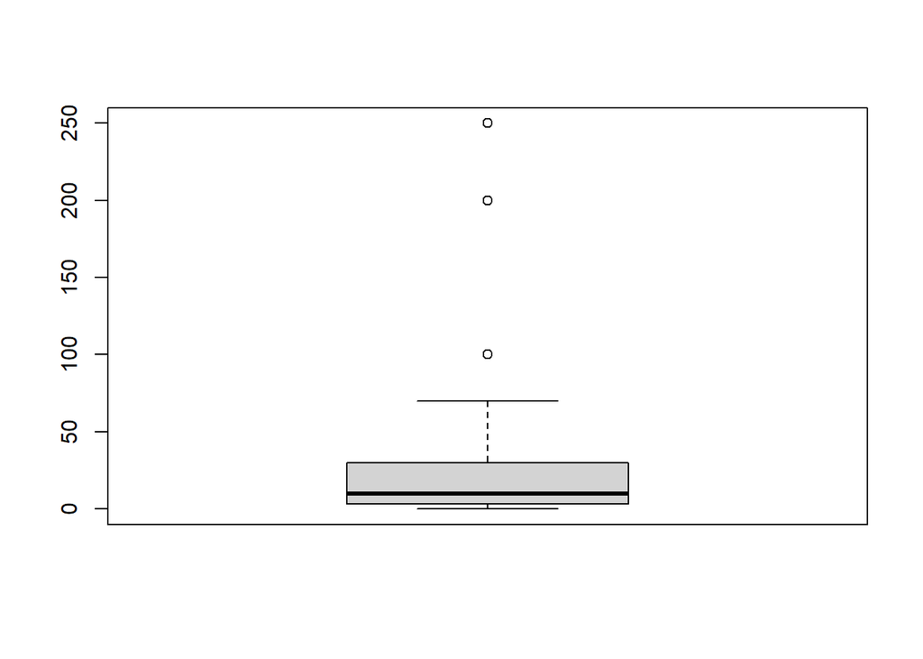

```r
boxplot(enquete$Berichten)
```

De plot hierboven heeft een nadeel. De centrale “box” van de boxplot is wat samengepropt onderaan de figuur. Dat komt door enkele observaties met extreem hoge waarden (uitschieters). Het is mogelijk om meer te focussen op de regio waar het overgrote deel van de gevallen zich bevinden, namelijk tussen waarden 0 en 100. Daartoe passen we gewoon de grenzen van de verticale as aan met het argument `ylim`.

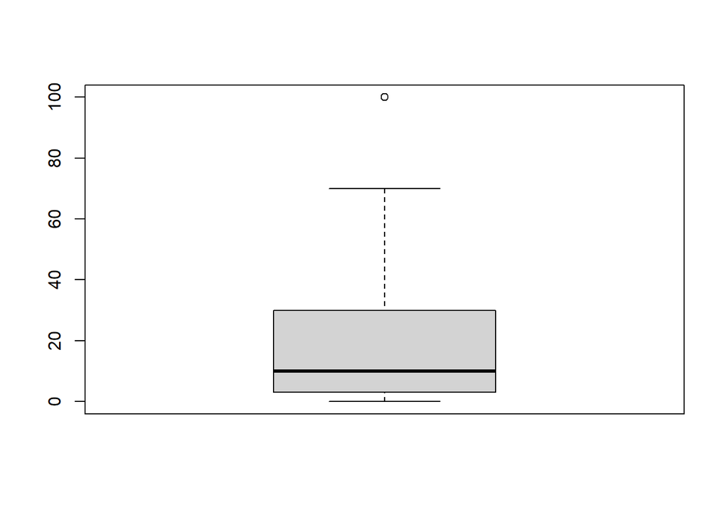

```r
boxplot(enquete$Berichten, ylim=c(0,100))
```

Merk op dat de uitschieters nu buiten de plot vallen maar wel nog in de dataset zitten. De boxplot zelf is dus op geen enkele manier veranderd!

Selectief visualiseren van data kan misleidend zijn. Bovenstaande grafiek kan nuttig zijn voor eigen gebruik, maar het is af te raden om ze te delen met anderen. Als je dat toch doet, dan moet je duidelijk maken hoe en waarom de selectie van data is gebeurd!

# 6 Meerdere boxplots

Het kan ook interessant zijn om de verdeling van een variabele in verschillende groepen met elkaar te vergelijken. Daartoe kan je meerdere boxplots naast elkaar plaatsen in dezelfde grafiek. Bijvoorbeeld, om de verdeling van het aantal gestuurde berichten (`Berichten`) te vergelijken tussen mannen en vrouwen (`Geslacht`) kan je onderstaande code gebruiken. De tilde `~` in het commando kan je lezen als “opgesplitst volgens …”.

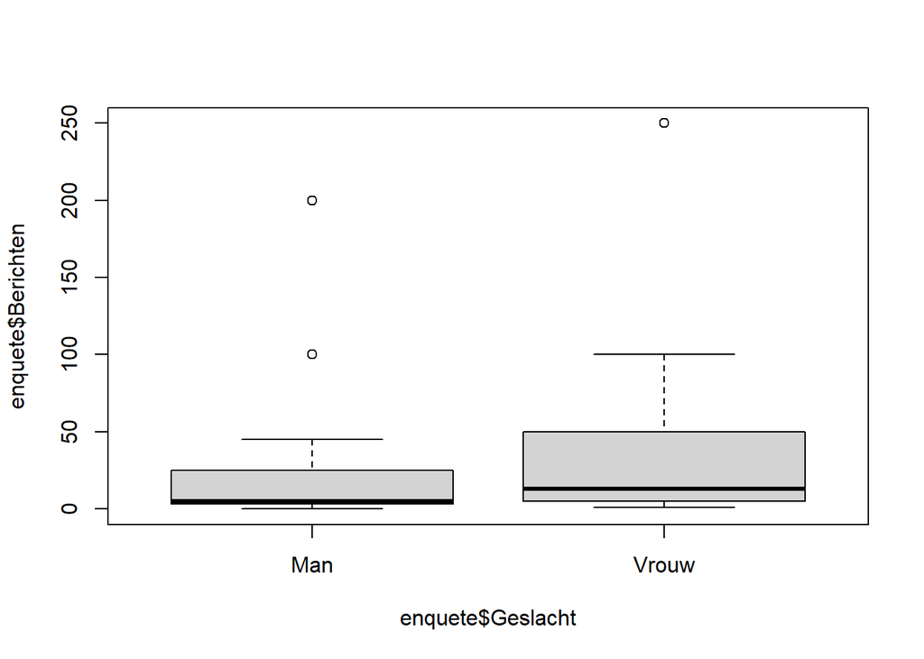

```r
boxplot(enquete$Berichten ~ enquete$Geslacht)
```

Opnieuw zijn de boxplots wat samengepropt. Dat kan je -indien gewenst- verhelpen met het argument `ylim` (zie ook hierboven)

# 7 Scatterplot

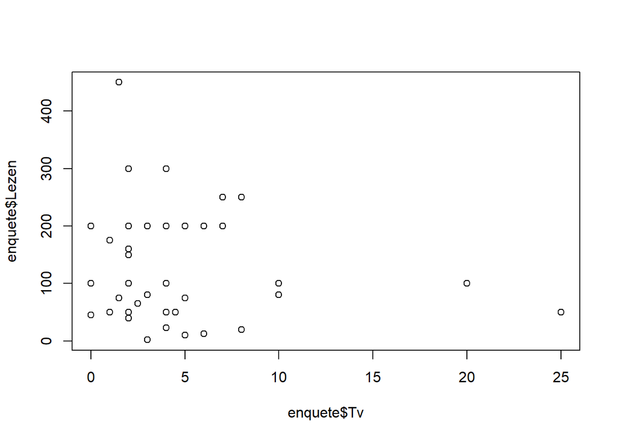

```r
plot(enquete$Tv, enquete$Lezen)
```

Het is mogelijk dat twee of meer studenten precies dezelfde waarde hebben voor zowel `Tv` als `Lezen`. In dat geval zullen ze in de scatterplot op dezelfde plaats terechtkomen. Het is bijgevolg niet duidelijk of een punt in de puntenwolk 1 observatie vertegenwoordigt, of 2 observaties of nog meer. Om dit probleem op te lossen kan je gebruik maken van de functie `jitter()`. Die voegt een zekere hoeveelheid willekeurige “ruis” toe aan de waarden. De hoeveelheid “ruis” controleer je met het argument `amount`.

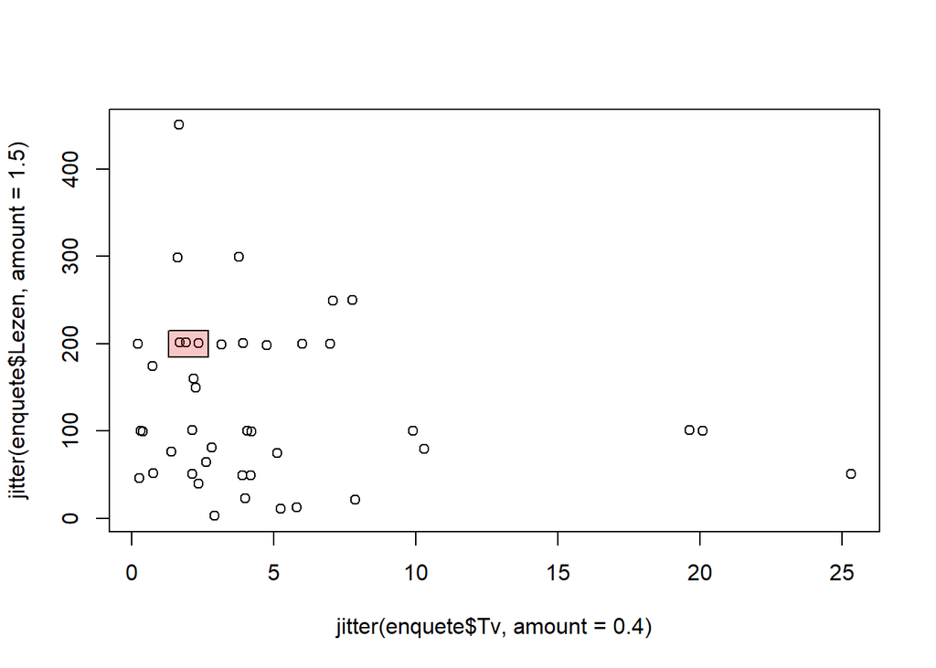

```r
plot(x=jitter(enquete$Tv, amount=0.4), y=jitter(enquete$Lezen, amount=1.5))
```

Je ziet onder andere in de rood gekleurde regio inderdaad dat er enkele punten “achter elkaar” verscholen zaten.

Zoals je het argument `ylim` eventueel kan gebruiken om te bepalen welk deel van de verticale as wordt getoond, zo kan je `xlim` gebruiken voor de horizontale as.

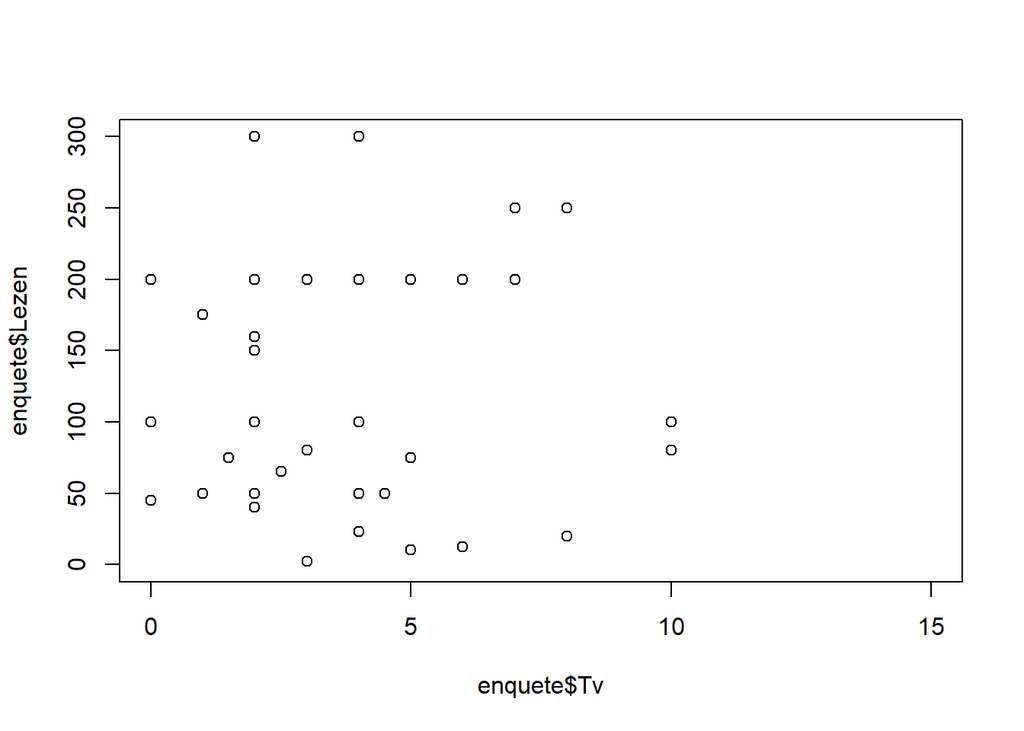

```r
plot(enquete$Tv, enquete$Lezen, xlim=c(0,15), ylim=c(0,300))
```

Selectief visualiseren van data kan misleidend zijn. Bovenstaande grafiek kan nuttig zijn voor eigen gebruik, maar het is af te raden om ze te delen met anderen. Als je dat toch doet, dan moet je duidelijk maken hoe en waarom de selectie van data is gebeurd!

# 8 Een grafiek afwerken

De functies hierboven bevatten vaak heel wat argumenten waarmee je de grafiek kan afwerken. Hieronder vind je code om een titel en astitels toe te voegen of aan te passen bij een scatterplot. (De argumenten staan onder elkaar voor de leesbaarheid.)

Bij de astitels kan je best ook de meeteenheid meegeven (indien van toepassing).

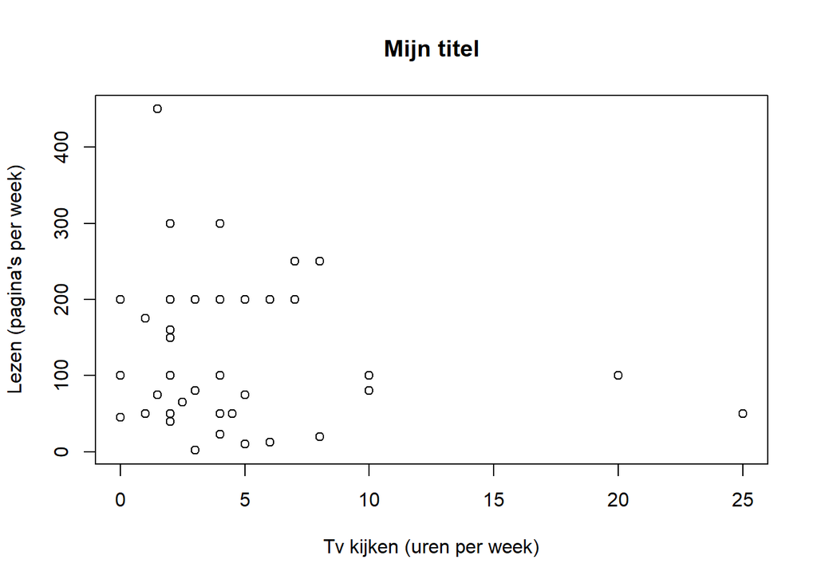

```r
plot(x=enquete$Tv,
     y=enquete$Lezen,
     main='Mijn titel',                   # hoofdtitel
     xlab='Tv kijken (uren per week)',    # titel voor horizontale as
     ylab='Lezen (pagina\'s per week)'    # titel voor verticale as
    )
```

Daarnaast heb je heel wat keuzes voor de presentatie van de informatie zelf. Deze grafische parameters kan je natuurlijk combineren met een titel en astitels, zoals hierboven.

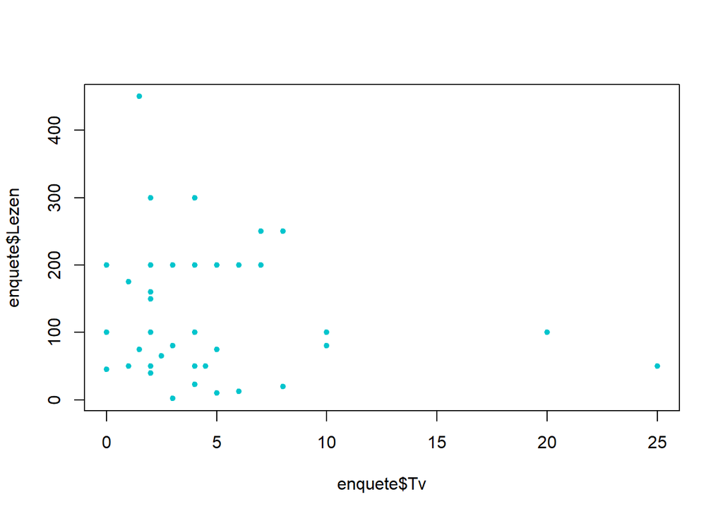

```r
plot(enquete$Tv,
     enquete$Lezen,
     pch=19,                          # kies het soort punt
     col='turquoise3',                # kies de kleur
     cex=0.7                          # kies de grootte van het punt (waarden groter dan 1 vergroten het punt)
    )
```

R heeft heel wat ingebouwde kleuren. De volledige lijst kan je opvragen door het commando `colors()` uit te voeren. Een overzicht waar je de kleuren erbij kan zien vind je [hier](http://www.stat.columbia.edu/~tzheng/files/Rcolor.pdf).

# 9 Een scatterplot met kleur

Een grafiek kan informatie bevatten over meer dan twee variabelen. Bijvoorbeeld door gebruik te maken van kleur kan je een derde variabele afbeelden. Hieronder vind je code voor een scatterplot, waarbij de observaties worden opgedeeld volgens de waarden van een derde variabele. Die laatste is degene die wordt weergegeven aan de hand van kleuren.

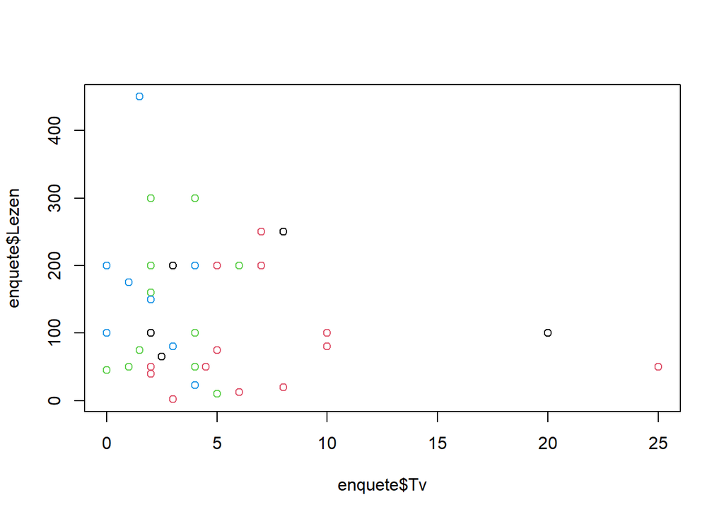

```r
plot(x=enquete$Tv,
     y=enquete$Lezen,
     col=enquete$Jaar                        # deze variabele moet van type factor zijn
     )
```

Deze grafiek heeft nog wat verduidelijking nodig. De kleur van de verschillende punten is niet altijd even duidelijk omdat het ‘punt’ eigenlijk een holle cirkel is. Daarom veranderen we het type punt. Bovendien valt moeilijk te achterhalen wat elke kleur precies betekent. Daarom voegen we een legende toe.

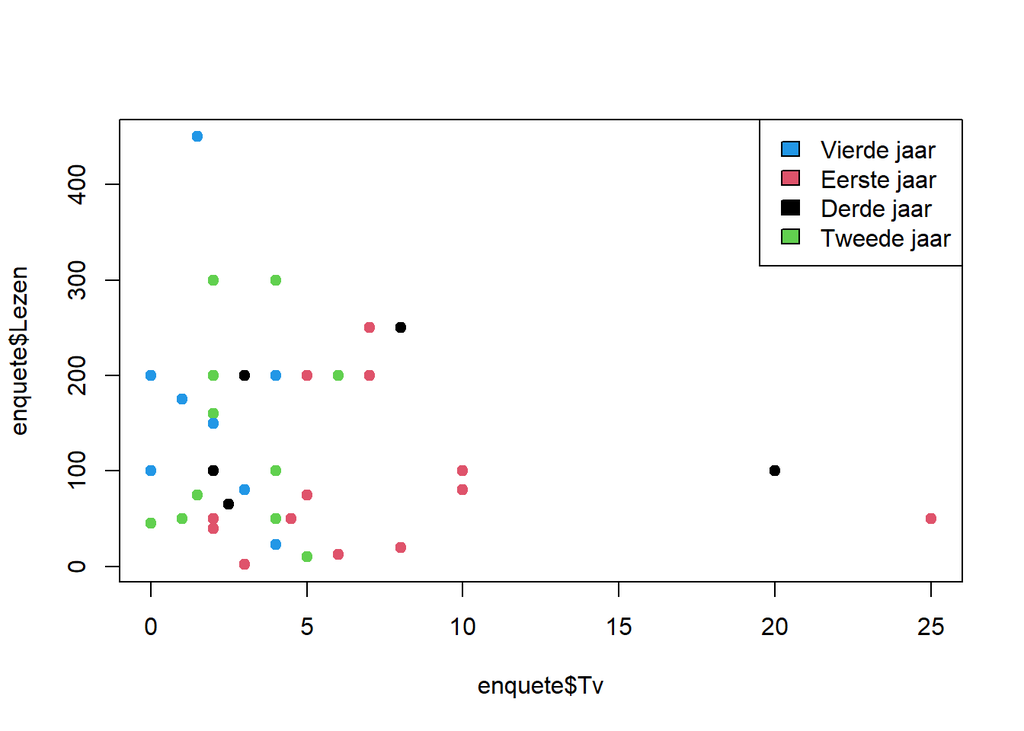

```r
plot(x=enquete$Tv,
     y=enquete$Lezen,
     col=enquete$Jaar,
     pch=19)

legend('topright',                          # positie van de legende vastleggen. Kan ook met coördinaten x en y
       legend=unique(enquete$Jaar),
       fill=unique(enquete$Jaar))           # argument col kan ook, maar leidt soms tot problemen met de weergave
```

Hieronder vind je terug hoe je zelf kan bepalen welke kleuren worden gebruikt.

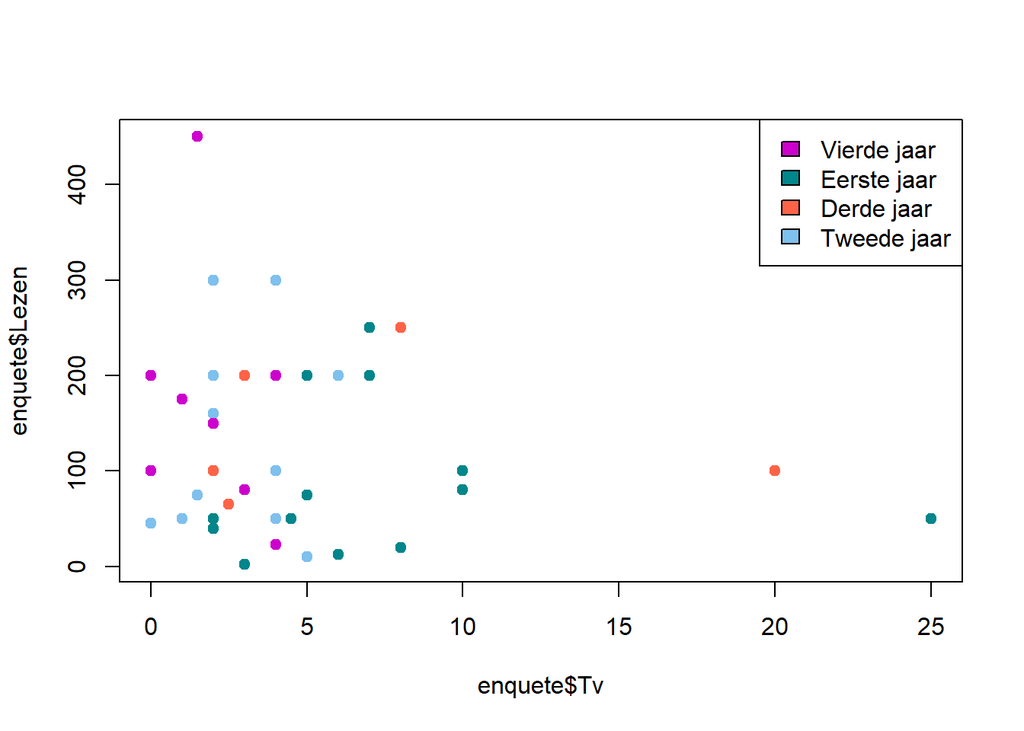

```r
mijn.kleuren <- c('tomato', 'turquoise4', 'skyblue2', 'magenta3')   # specifieer evenveel kleuren als er niveaus zijn in de categorische variabele

plot(x=enquete$Tv,
     y=enquete$Lezen,
     pch=19,
     col=mijn.kleuren[enquete$Jaar])

legend('topright',
       legend=unique(enquete$Jaar),
       fill=mijn.kleuren[unique(enquete$Jaar)])
```

# 10 Een plot exporteren

Wanneer je een grafiek hebt gemaakt zal je die misschien willen opslaan om later op te nemen in bijvoorbeeld een Worddocument of Powerpointpresentatie.

Je kan een plot opslaan door die te creëren tussen twee commando’s:

- `png('titel.png')`
- `dev.off()`

Bijvoorbeeld,

```r
png('mijngrafiek.png', width=400, height=500)

plot(x=enquete$Tv, y=enquete$Lezen, col=enquete$Jaar)

dev.off()
```

Het resultaat zal zijn dat in je working directory een bestand verschijnt met de naam “mijngrafiek.png”. Uiteraard kan je kiezen voor een andere naam dan “mijngrafiek”. De extensie “.png” is iets technisch dat verwijst naar het type afbeelding. Als je dat wil kan je de breedte en hoogte van de figuur aanpassen met de argumenten `width` en `height`. Standaard zijn ze allebei vastgelegd op 480 pixels.

In plaats van een png-bestand kan je ook een pdf maken. Het principe is hetzelfde: creëer de grafiek tussen twee commando’s. Kies eventueel een `width` en een `height`. Standaard zijn die ingesteld op 7 inches (dus niet pixels zoals bij `png()`).

```r
pdf('mijngrafiek.pdf', width=8, height=4)

plot(x=enquete$Tv, y=enquete$Lezen, col=enquete$Jaar)

dev.off()
```

# 11 Meer info

In de beknopte demonstraties hierboven hebben we telkens maar een klein tipje van de sluier gelicht. Er zijn veel meer mogelijkheden. Sommige ervan vind je in deze [“cheat sheet”](http://publish.illinois.edu/johnrgallagher/files/2015/10/BaseGraphicsCheatsheet.pdf). Ook Google of AI-chatbots kunnen je natuurlijk verderhelpen.